# Analyse en Composantes Principales

Jeu de données donb

Ce jeu de données contient 5581 individus et 46 variables.

### 1. Observation d’individus extrêmes

L’analyse des graphes ne révèle aucun individu singulier.

### 2. Distribution de l’inertie

L’inertie des axes factoriels indique d’une part si les variables sont structurées et suggère d’autre part le nombre judicieux de composantes principales à étudier.

Les 2 premiers axes de l’ ACP expriment **47.4%** de l’inertie totale du jeu de données ; cela signifie que 47.4% de la variabilité totale du nuage des individus (ou des variables) est représentée dans ce plan. C’est un pourcentage relativement moyen, et le premier plan représente donc seulement une part de la variabilité contenue dans l’ensemble du jeu de données actif. Cette valeur est nettement supérieure à la valeur référence de **5.13%**, la variabilité expliquée par ce plan est donc hautement significative (cette intertie de référence est le quantile 0.95 de la distribution des pourcentages d’inertie obtenus en simulant 153 jeux de données aléatoires de dimensions comparables sur la base d’une distribution normale).

Du fait de ces observations, il serait alors probablement nécessaire de considérer également les dimensions supérieures ou égales à la troisième dans l’analyse.

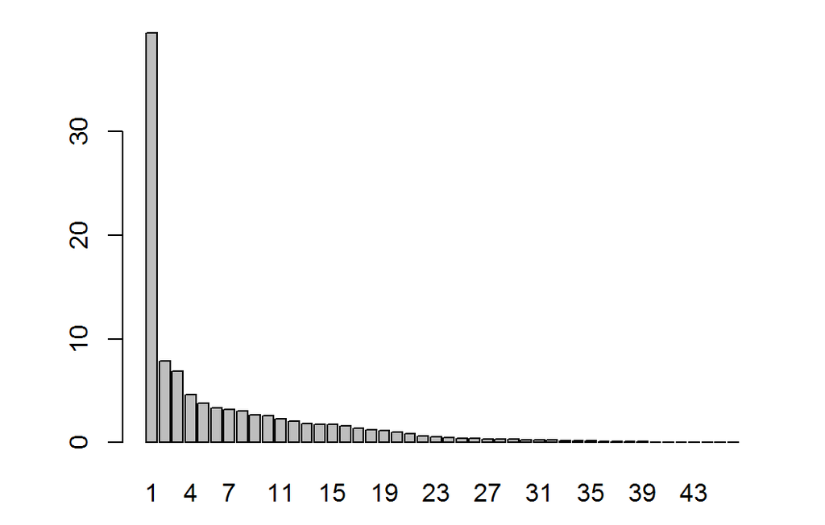

**Figure 2 - Decomposition of the total inertia on the components of the ACP**

Une estimation du nombre pertinent d’axes à interpréter suggère de restreindre l’analyse à la description des 10 premiers axes. Ces composantes révèlent un taux d’inertie supérieur à celle du quantile 0.95 de distributions aléatoires (77.59% contre 24.59%). Cette observation suggère que seuls ces axes sont porteurs d’une véritable information. En conséquence, la description de l’analyse sera restreinte à ces seuls axes.

### 3. Description du plan 1:2

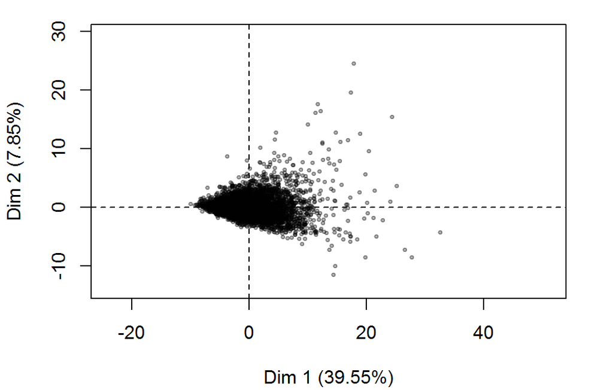

**Figure 3.1 - Graphe des individus (ACP)** *Les individus libellés sont ceux ayant la plus grande contribution à la construction du plan.*

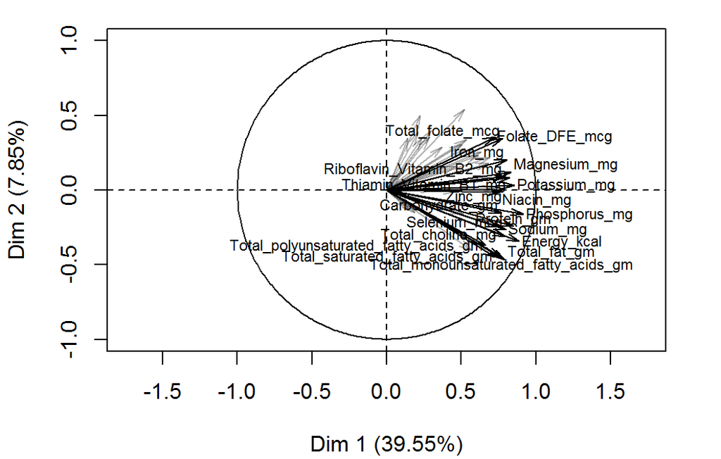

**Figure 3.2 - Graphe des variables (ACP)** *Les variables libellées sont celles les mieux représentées sur le plan.*

La **dimension 1** oppose des individus caractérisés par une coordonnée fortement positive sur l’axe (à droite du graphe) à des individus caractérisés par une coordonnée fortement négative sur l’axe (à gauche du graphe).

Le groupe 1 (caractérisés par une coordonnée positive sur l’axe) partage :

- de fortes valeurs pour des variables telles que *Phosphorus_mg*, *Energy_kcal*, *Protein_gm*, *Potassium_mg*, *Selenium_mcg*, *Sodium_mg*, *Total_fat_gm*, *Magnesium_mg*, *Total_monounsaturated_fatty_acids_gm* et *Carbohydrate_gm* (de la plus extrême à la moins extrême).

Le groupe 2 (caractérisés par une coordonnée positive sur l’axe) partage :

- de fortes valeurs pour des variables telles que *Total_folate_mcg*, *Folate_DFE_mcg*, *Iron_mg*, *Folic_acid_mcg*, *Riboflavin_Vitamin_B2_mg*, *Vitamin_A_RAE_mcg*, *tocopherol_mg*, *Vitamin_B12_mcg*, *Zinc_mg* et *Thiamin_Vitamin_B1_mg* (de la plus extrême à la moins extrême).

Le groupe 3 (caractérisés par une coordonnées négative sur l’axe) partage :

- de faibles valeurs pour des variables telles que *Phosphorus_mg*, *Energy_kcal*, *Potassium_mg*, *Protein_gm*, *Magnesium_mg*, *Thiamin_Vitamin_B1_mg*, *Riboflavin_Vitamin_B2_mg*, *Zinc_mg*, *Niacin_mg* et *Selenium_mcg* (de la plus extrême à la moins extrême).

La **dimension 2** oppose des individus caractérisés par une coordonnée fortement positive sur l’axe (en haut du graphe) à des individus caractérisés par une coordonnée fortement négative sur l’axe (en bas du graphe).

Le groupe 1 (caractérisés par une coordonnée positive sur l’axe) partage :

- de faibles valeurs pour des variables telles que *Phosphorus_mg*, *Energy_kcal*, *Potassium_mg*, *Protein_gm*, *Magnesium_mg*, *Thiamin_Vitamin_B1_mg*, *Riboflavin_Vitamin_B2_mg*, *Zinc_mg*, *Niacin_mg* et *Selenium_mcg* (de la plus extrême à la moins extrême).

Le groupe 2 (caractérisés par une coordonnée positive sur l’axe) partage :

- de fortes valeurs pour des variables telles que *Total_folate_mcg*, *Folate_DFE_mcg*, *Iron_mg*, *Folic_acid_mcg*, *Riboflavin_Vitamin_B2_mg*, *Vitamin_A_RAE_mcg*, *tocopherol_mg*, *Vitamin_B12_mcg*, *Zinc_mg* et *Thiamin_Vitamin_B1_mg* (de la plus extrême à la moins extrême).

Le groupe 3 (caractérisés par une coordonnées négative sur l’axe) partage :

- de fortes valeurs pour des variables telles que *Phosphorus_mg*, *Energy_kcal*, *Protein_gm*, *Potassium_mg*, *Selenium_mcg*, *Sodium_mg*, *Total_fat_gm*, *Magnesium_mg*, *Total_monounsaturated_fatty_acids_gm* et *Carbohydrate_gm* (de la plus extrême à la moins extrême).

### 4. Description du plan 3:4

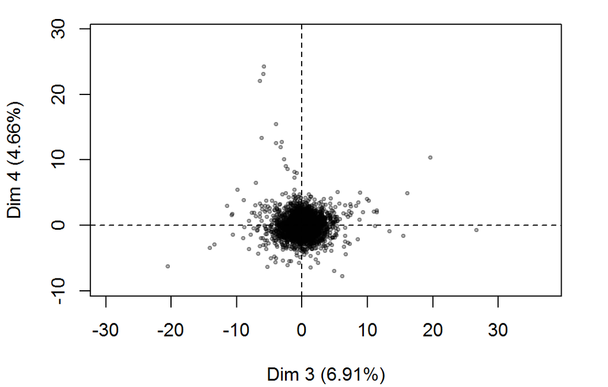

**Figure 4.1 - Graphe des individus (ACP)** *Les individus libellés sont ceux ayant la plus grande contribution à la construction du plan.*

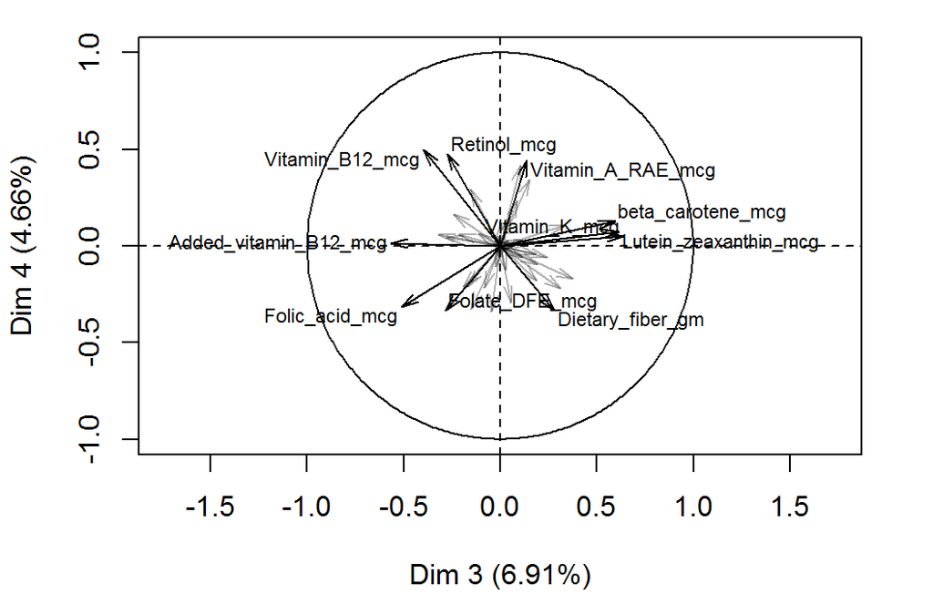

**Figure 4.2 - Graphe des variables (ACP)** *Les variables libellées sont celles les mieux représentées sur le plan.*

La **dimension 3** oppose des individus caractérisés par une coordonnée fortement positive sur l’axe (à droite du graphe) à des individus caractérisés par une coordonnée fortement négative sur l’axe (à gauche du graphe).

Le groupe 1 (caractérisés par une coordonnée positive sur l’axe) partage :

- de fortes valeurs pour des variables telles que *beta_carotene_mcg*, *Vitamin_K_mcg*, *Lutein_zeaxanthin_mcg*, *Food_folate_mcg*, *Vitamin_C_mg*, *Potassium_mg*, *Dietary_fiber_gm*, *Magnesium_mg*, *alpha_carotene_mcg* et *Moisture_gm* (de la plus extrême à la moins extrême).
- de faibles valeurs pour des variables telles que *Folic_acid_mcg*, *Added_vitamin_B12_mcg*, *Vitamin_B12_mcg*, *Niacin_mg*, *Folate_DFE_mcg*, *Iron_mg*, *Thiamin_Vitamin_B1_mg*, *Retinol_mcg*, *Riboflavin_Vitamin_B2_mg* et *Vitamin_D_D2_D3_mcg* (de la plus extrême à la moins extrême).

Le groupe 2 (caractérisés par une coordonnées négative sur l’axe) partage :

- de fortes valeurs pour des variables telles que *Folic_acid_mcg*, *Folate_DFE_mcg*, *Iron_mg*, *Thiamin_Vitamin_B1_mg*, *Carbohydrate_gm*, *Total_folate_mcg*, *Added_vitamin_B12_mcg*, *Total_sugars_gm*, *Niacin_mg* et *Vitamin_B6_mg* (de la plus extrême à la moins extrême).
- de faibles valeurs pour des variables telles que *Total_choline_mg*, *Cholesterol_mg*, *beta_carotene_mcg*, *Vitamin_K_mcg*, *Lutein_zeaxanthin_mcg*, *Vitamin_A_RAE_mcg*, *Protein_gm*, *alpha_carotene_mcg*, *Potassium_mg* et *Moisture_gm* (de la plus extrême à la moins extrême).

Le groupe 3 (caractérisés par une coordonnées négative sur l’axe) partage :

- de fortes valeurs pour des variables telles que *Cholesterol_mg*, *Total_choline_mg*, *Vitamin_D_D2_D3_mcg*, *Protein_gm*, *Selenium_mcg*, *Retinol_mcg*, *Vitamin_B12_mcg*, *Phosphorus_mg*, *Total_saturated_fatty_acids_gm* et *Total_monounsaturated_fatty_acids_gm* (de la plus extrême à la moins extrême).
- de faibles valeurs pour des variables telles que *Dietary_fiber_gm*, *Total_folate_mcg*, *Carbohydrate_gm*, *Folate_DFE_mcg*, *Thiamin_Vitamin_B1_mg*, *Iron_mg*, *Folic_acid_mcg*, *Vitamin_C_mg*, *Food_folate_mcg* et *Total_sugars_gm* (de la plus extrême à la moins extrême).

La **dimension 4** oppose des individus caractérisés par une coordonnée fortement positive sur l’axe (en haut du graphe) à des individus caractérisés par une coordonnée fortement négative sur l’axe (en bas du graphe).

Le groupe 1 (caractérisés par une coordonnée positive sur l’axe) partage :

- de fortes valeurs pour des variables telles que *Cholesterol_mg*, *Total_choline_mg*, *Vitamin_D_D2_D3_mcg*, *Protein_gm*, *Selenium_mcg*, *Retinol_mcg*, *Vitamin_B12_mcg*, *Phosphorus_mg*, *Total_saturated_fatty_acids_gm* et *Total_monounsaturated_fatty_acids_gm* (de la plus extrême à la moins extrême).
- de faibles valeurs pour des variables telles que *Dietary_fiber_gm*, *Total_folate_mcg*, *Carbohydrate_gm*, *Folate_DFE_mcg*, *Thiamin_Vitamin_B1_mg*, *Iron_mg*, *Folic_acid_mcg*, *Vitamin_C_mg*, *Food_folate_mcg* et *Total_sugars_gm* (de la plus extrême à la moins extrême).

Le groupe 2 (caractérisés par une coordonnées négative sur l’axe) partage :

- de fortes valeurs pour des variables telles que *Folic_acid_mcg*, *Folate_DFE_mcg*, *Iron_mg*, *Thiamin_Vitamin_B1_mg*, *Carbohydrate_gm*, *Total_folate_mcg*, *Added_vitamin_B12_mcg*, *Total_sugars_gm*, *Niacin_mg* et *Vitamin_B6_mg* (de la plus extrême à la moins extrême).
- de faibles valeurs pour des variables telles que *Total_choline_mg*, *Cholesterol_mg*, *beta_carotene_mcg*, *Vitamin_K_mcg*, *Lutein_zeaxanthin_mcg*, *Vitamin_A_RAE_mcg*, *Protein_gm*, *alpha_carotene_mcg*, *Potassium_mg* et *Moisture_gm* (de la plus extrême à la moins extrême).

### 5. Description du plan 5:6

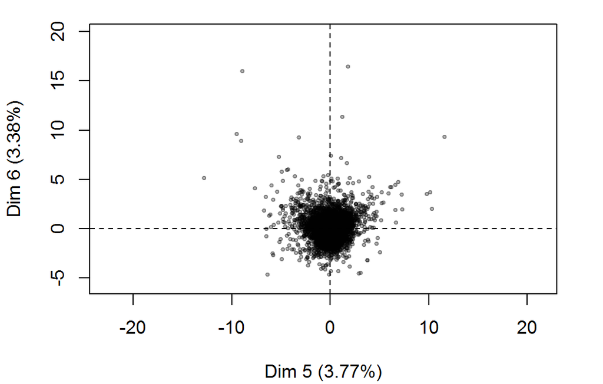

**Figure 5.1 - Graphe des individus (ACP)** *Les individus libellés sont ceux ayant la plus grande contribution à la construction du plan.*

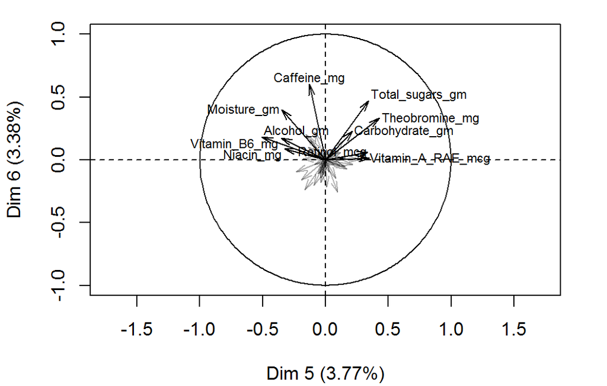

**Figure 5.2 - Graphe des variables (ACP)** *Les variables libellées sont celles les mieux représentées sur le plan.*

La **dimension 5** oppose des individus caractérisés par une coordonnée fortement positive sur l’axe (à droite du graphe) à des individus caractérisés par une coordonnée fortement négative sur l’axe (à gauche du graphe).

Le groupe 1 (caractérisés par une coordonnée positive sur l’axe) partage :

- de fortes valeurs pour des variables telles que *Folic_acid_mcg*, *Folate_DFE_mcg*, *Selenium_mcg*, *Cholesterol_mg*, *Total_folate_mcg*, *Sodium_mg*, *Iron_mg*, *Thiamin_Vitamin_B1_mg*, *Protein_gm* et *Total_polyunsaturated_fatty_acids_gm* (de la plus extrême à la moins extrême).
- de faibles valeurs pour des variables telles que *Moisture_gm*, *Total_sugars_gm*, *Caffeine_mg*, *Potassium_mg*, *Theobromine_mg*, *Magnesium_mg*, *Carbohydrate_gm*, *Alcohol_gm*, *Riboflavin_Vitamin_B2_mg* et *Vitamin_B6_mg* (de la plus extrême à la moins extrême).

Le groupe 2 (caractérisés par une coordonnée positive sur l’axe) partage :

- de fortes valeurs pour des variables telles que *Total_sugars_gm*, *Theobromine_mg*, *Carbohydrate_gm*, *Total_saturated_fatty_acids_gm*, *Vitamin_A_RAE_mcg*, *Retinol_mcg*, *Caffeine_mg*, *Energy_kcal*, *Total_fat_gm* et *Calcium_mg* (de la plus extrême à la moins extrême).
- de faibles valeurs pour des variables telles que *Selenium_mcg*, *Total_choline_mg*, *Protein_gm*, *Cholesterol_mg*, *Niacin_mg*, *Alcohol_gm*, *Vitamin_B6_mg*, *Total_folate_mcg*, *Sodium_mg* et *Folate_DFE_mcg* (de la plus extrême à la moins extrême).

Le groupe 3 (caractérisés par une coordonnées négative sur l’axe) partage :

- de fortes valeurs pour des variables telles que *Alcohol_gm*, *Moisture_gm*, *Niacin_mg*, *Vitamin_B6_mg*, *Food_folate_mcg*, *Total_choline_mg*, *Magnesium_mg*, *Potassium_mg*, *Added_vitamin_B12_mcg* et *Vitamin_B12_mcg* (de la plus extrême à la moins extrême).
- de faibles valeurs pour des variables telles que *Total_saturated_fatty_acids_gm*, *Retinol_mcg*, *Total_fat_gm*, *Theobromine_mg*, *Folic_acid_mcg*, *Total_sugars_gm*, *Vitamin_A_RAE_mcg*, *Carbohydrate_gm*, *Total_monounsaturated_fatty_acids_gm* et *Total_polyunsaturated_fatty_acids_gm* (de la plus extrême à la moins extrême).

La **dimension 6** oppose des individus caractérisés par une coordonnée fortement positive sur l’axe (en haut du graphe) à des individus caractérisés par une coordonnée fortement négative sur l’axe (en bas du graphe).

Le groupe 1 (caractérisés par une coordonnée positive sur l’axe) partage :

- de fortes valeurs pour des variables telles que *Alcohol_gm*, *Moisture_gm*, *Niacin_mg*, *Vitamin_B6_mg*, *Food_folate_mcg*, *Total_choline_mg*, *Magnesium_mg*, *Potassium_mg*, *Added_vitamin_B12_mcg* et *Vitamin_B12_mcg* (de la plus extrême à la moins extrême).
- de faibles valeurs pour des variables telles que *Total_saturated_fatty_acids_gm*, *Retinol_mcg*, *Total_fat_gm*, *Theobromine_mg*, *Folic_acid_mcg*, *Total_sugars_gm*, *Vitamin_A_RAE_mcg*, *Carbohydrate_gm*, *Total_monounsaturated_fatty_acids_gm* et *Total_polyunsaturated_fatty_acids_gm* (de la plus extrême à la moins extrême).

Le groupe 2 (caractérisés par une coordonnée positive sur l’axe) partage :

- de fortes valeurs pour des variables telles que *Total_sugars_gm*, *Theobromine_mg*, *Carbohydrate_gm*, *Total_saturated_fatty_acids_gm*, *Vitamin_A_RAE_mcg*, *Retinol_mcg*, *Caffeine_mg*, *Energy_kcal*, *Total_fat_gm* et *Calcium_mg* (de la plus extrême à la moins extrême).
- de faibles valeurs pour des variables telles que *Selenium_mcg*, *Total_choline_mg*, *Protein_gm*, *Cholesterol_mg*, *Niacin_mg*, *Alcohol_gm*, *Vitamin_B6_mg*, *Total_folate_mcg*, *Sodium_mg* et *Folate_DFE_mcg* (de la plus extrême à la moins extrême).

Le groupe 3 (caractérisés par une coordonnées négative sur l’axe) partage :

- de fortes valeurs pour des variables telles que *Folic_acid_mcg*, *Folate_DFE_mcg*, *Selenium_mcg*, *Cholesterol_mg*, *Total_folate_mcg*, *Sodium_mg*, *Iron_mg*, *Thiamin_Vitamin_B1_mg*, *Protein_gm* et *Total_polyunsaturated_fatty_acids_gm* (de la plus extrême à la moins extrême).
- de faibles valeurs pour des variables telles que *Moisture_gm*, *Total_sugars_gm*, *Caffeine_mg*, *Potassium_mg*, *Theobromine_mg*, *Magnesium_mg*, *Carbohydrate_gm*, *Alcohol_gm*, *Riboflavin_Vitamin_B2_mg* et *Vitamin_B6_mg* (de la plus extrême à la moins extrême).

### 6. Description du plan 7:8

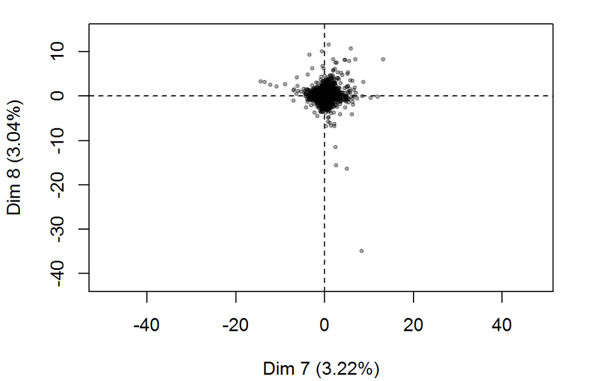

**Figure 6.1 - Graphe des individus (ACP)** *Les individus libellés sont ceux ayant la plus grande contribution à la construction du plan.*

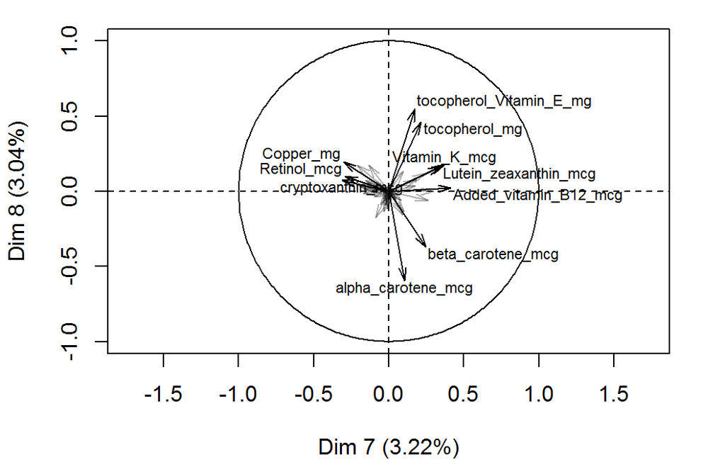

**Figure 6.2 - Graphe des variables (ACP)** *Les variables libellées sont celles les mieux représentées sur le plan.*

La **dimension 7** oppose des individus caractérisés par une coordonnée fortement positive sur l’axe (à droite du graphe) à des individus caractérisés par une coordonnée fortement négative sur l’axe (à gauche du graphe).

Le groupe 1 (caractérisés par une coordonnée positive sur l’axe) partage :

- de fortes valeurs pour des variables telles que *Niacin_mg*, *Sodium_mg*, *Total_polyunsaturated_fatty_acids_gm*, *beta_carotene_mcg*, *Total_fat_gm*, *Added_vitamin_B12_mcg*, *Vitamin_K_mcg*, *Vitamin_B6_mg*, *Total_monounsaturated_fatty_acids_gm* et *Total_saturated_fatty_acids_gm* (de la plus extrême à la moins extrême).
- de faibles valeurs pour des variables telles que *Vitamin_C_mg*, *Magnesium_mg*, *Calcium_mg*, *Dietary_fiber_gm*, *Potassium_mg*, *Food_folate_mcg*, *Vitamin_D_D2_D3_mcg*, *Moisture_gm*, *Copper_mg* et *cryptoxanthin_mcg* (de la plus extrême à la moins extrême).

Le groupe 2 (caractérisés par une coordonnée positive sur l’axe) partage :

- de fortes valeurs pour des variables telles que *alpha_carotene_mcg*, *beta_carotene_mcg*, *Vitamin_A_RAE_mcg*, *Dietary_fiber_gm*, *Potassium_mg*, *Iron_mg*, *Total_folate_mcg*, *Folate_DFE_mcg*, *Added_vitamin_B12_mcg* et *Thiamin_Vitamin_B1_mg* (de la plus extrême à la moins extrême).

Le groupe 3 (caractérisés par une coordonnées négative sur l’axe) partage :

- de fortes valeurs pour des variables telles que *cryptoxanthin_mcg*, *Food_folate_mcg*, *Calcium_mg*, *Vitamin_C_mg*, *Lycopene_mcg*, *Dietary_fiber_gm*, *Potassium_mg*, *Vitamin_D_D2_D3_mcg*, *Phosphorus_mg* et *Moisture_gm* (de la plus extrême à la moins extrême).
- de faibles valeurs pour des variables telles que *Total_polyunsaturated_fatty_acids_gm*, *Total_monounsaturated_fatty_acids_gm*, *tocopherol_mg*, *Total_fat_gm*, *Added_vitamin_B12_mcg*, *Niacin_mg*, *tocopherol_Vitamin_E_mg*, *Vitamin_K_mcg*, *beta_carotene_mcg* et *Vitamin_B6_mg* (de la plus extrême à la moins extrême).

La **dimension 8** oppose des individus caractérisés par une coordonnée fortement positive sur l’axe (en haut du graphe) à des individus caractérisés par une coordonnée fortement négative sur l’axe (en bas du graphe).

Le groupe 1 (caractérisés par une coordonnée positive sur l’axe) partage :

- de fortes valeurs pour des variables telles que *tocopherol_mg*, *tocopherol_Vitamin_E_mg*, *Magnesium_mg*, *Total_monounsaturated_fatty_acids_gm*, *Vitamin_C_mg*, *Copper_mg*, *Theobromine_mg*, *Dietary_fiber_gm*, *Total_polyunsaturated_fatty_acids_gm* et *Moisture_gm* (de la plus extrême à la moins extrême).
- de faibles valeurs pour des variables telles que *Sodium_mg*, *alpha_carotene_mcg*, *beta_carotene_mcg*, *Cholesterol_mg*, *Carbohydrate_gm*, *Selenium_mcg*, *Total_sugars_gm*, *Folic_acid_mcg*, *Niacin_mg* et *Total_saturated_fatty_acids_gm* (de la plus extrême à la moins extrême).

Le groupe 2 (caractérisés par une coordonnées négative sur l’axe) partage :

- de fortes valeurs pour des variables telles que *cryptoxanthin_mcg*, *Food_folate_mcg*, *Calcium_mg*, *Vitamin_C_mg*, *Lycopene_mcg*, *Dietary_fiber_gm*, *Potassium_mg*, *Vitamin_D_D2_D3_mcg*, *Phosphorus_mg* et *Moisture_gm* (de la plus extrême à la moins extrême).
- de faibles valeurs pour des variables telles que *Total_polyunsaturated_fatty_acids_gm*, *Total_monounsaturated_fatty_acids_gm*, *tocopherol_mg*, *Total_fat_gm*, *Added_vitamin_B12_mcg*, *Niacin_mg*, *tocopherol_Vitamin_E_mg*, *Vitamin_K_mcg*, *beta_carotene_mcg* et *Vitamin_B6_mg* (de la plus extrême à la moins extrême).

Le groupe 3 (caractérisés par une coordonnées négative sur l’axe) partage :

- de fortes valeurs pour des variables telles que *Niacin_mg*, *Sodium_mg*, *Total_polyunsaturated_fatty_acids_gm*, *beta_carotene_mcg*, *Total_fat_gm*, *Added_vitamin_B12_mcg*, *Vitamin_K_mcg*, *Vitamin_B6_mg*, *Total_monounsaturated_fatty_acids_gm* et *Total_saturated_fatty_acids_gm* (de la plus extrême à la moins extrême).
- de faibles valeurs pour des variables telles que *Vitamin_C_mg*, *Magnesium_mg*, *Calcium_mg*, *Dietary_fiber_gm*, *Potassium_mg*, *Food_folate_mcg*, *Vitamin_D_D2_D3_mcg*, *Moisture_gm*, *Copper_mg* et *cryptoxanthin_mcg* (de la plus extrême à la moins extrême).

Le groupe 4 (caractérisés par une coordonnées négative sur l’axe) partage :

- de fortes valeurs pour des variables telles que *alpha_carotene_mcg*, *beta_carotene_mcg*, *Vitamin_A_RAE_mcg*, *Dietary_fiber_gm*, *Potassium_mg*, *Iron_mg*, *Total_folate_mcg*, *Folate_DFE_mcg*, *Added_vitamin_B12_mcg* et *Thiamin_Vitamin_B1_mg* (de la plus extrême à la moins extrême).

### 7. Description du plan 9:10

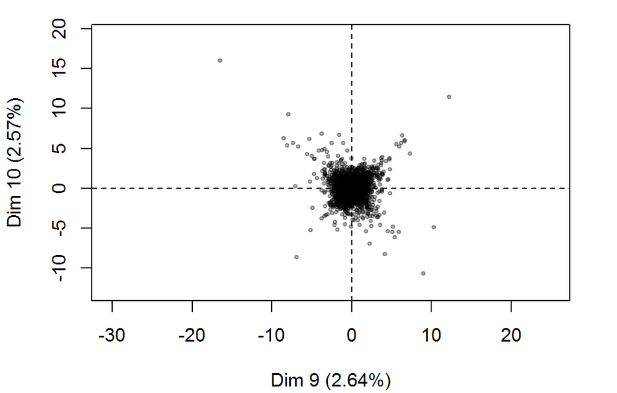

**Figure 7.1 - Graphe des individus (ACP)** *Les individus libellés sont ceux ayant la plus grande contribution à la construction du plan.*

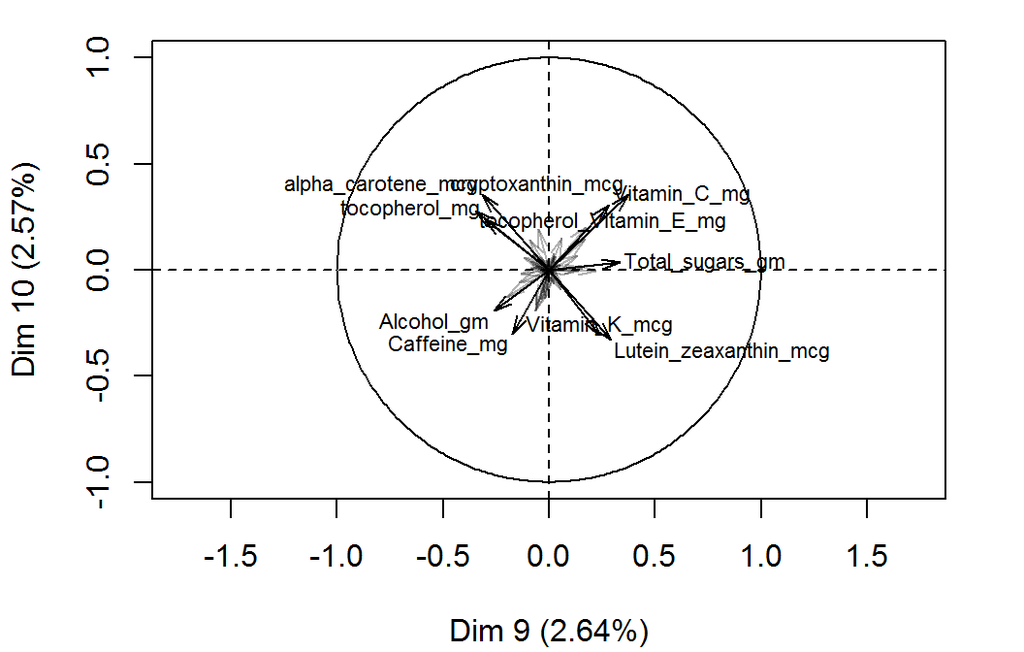

**Figure 7.2 - Graphe des variables (ACP)** *Les variables libellées sont celles les mieux représentées sur le plan.*

La **dimension 9** oppose des individus caractérisés par une coordonnée fortement positive sur l’axe (à droite du graphe) à des individus caractérisés par une coordonnée fortement négative sur l’axe (à gauche du graphe).

Le groupe 1 (caractérisés par une coordonnée positive sur l’axe) partage :

- de fortes valeurs pour des variables telles que *Vitamin_C_mg*, *cryptoxanthin_mcg*, *Total_sugars_gm*, *Cholesterol_mg*, *Vitamin_B6_mg*, *Lycopene_mcg*, *Vitamin_B12_mcg*, *Carbohydrate_gm*, *Added_vitamin_B12_mcg* et *Niacin_mg* (de la plus extrême à la moins extrême).
- de faibles valeurs pour des variables telles que *Folate_DFE_mcg*, *Total_folate_mcg*, *Caffeine_mg*, *Moisture_gm*, *Folic_acid_mcg*, *Alcohol_gm*, *Iron_mg*, *Vitamin_K_mcg*, *Lutein_zeaxanthin_mcg* et *Retinol_mcg* (de la plus extrême à la moins extrême).

Le groupe 2 (caractérisés par une coordonnée positive sur l’axe) partage :

- de fortes valeurs pour des variables telles que *Lutein_zeaxanthin_mcg*, *Vitamin_K_mcg*, *Vitamin_D_D2_D3_mcg*, *Total_sugars_gm*, *Retinol_mcg*, *Vitamin_A_RAE_mcg*, *Calcium_mg*, *Total_folate_mcg*, *beta_carotene_mcg* et *Folate_DFE_mcg* (de la plus extrême à la moins extrême).
- de faibles valeurs pour des variables telles que *Lycopene_mcg*, *tocopherol_mg*, *Moisture_gm*, *Alcohol_gm*, *tocopherol_Vitamin_E_mg*, *alpha_carotene_mcg*, *Total_polyunsaturated_fatty_acids_gm*, *Total_monounsaturated_fatty_acids_gm*, *Niacin_mg* et *Copper_mg* (de la plus extrême à la moins extrême).

Le groupe 3 (caractérisés par une coordonnées négative sur l’axe) partage :

- de fortes valeurs pour des variables telles que *tocopherol_Vitamin_E_mg*, *tocopherol_mg*, *Vitamin_A_RAE_mcg*, *alpha_carotene_mcg*, *beta_carotene_mcg*, *Copper_mg*, *Magnesium_mg*, *Dietary_fiber_gm*, *Retinol_mcg* et *Zinc_mg* (de la plus extrême à la moins extrême).
- de faibles valeurs pour les variables *Caffeine_mg* et *Lutein_zeaxanthin_mcg* (de la plus extrême à la moins extrême).

Le groupe 4 (caractérisés par une coordonnées négative sur l’axe) partage :

- de fortes valeurs pour des variables telles que *Caffeine_mg*, *Alcohol_gm*, *Moisture_gm*, *Folate_DFE_mcg*, *Total_folate_mcg*, *Folic_acid_mcg*, *Total_monounsaturated_fatty_acids_gm*, *Total_polyunsaturated_fatty_acids_gm*, *Total_fat_gm* et *Magnesium_mg* (de la plus extrême à la moins extrême).
- de faibles valeurs pour des variables telles que *Vitamin_C_mg*, *Total_sugars_gm*, *Vitamin_D_D2_D3_mcg*, *Vitamin_B12_mcg*, *Vitamin_B6_mg*, *cryptoxanthin_mcg*, *Vitamin_A_RAE_mcg*, *Cholesterol_mg*, *Carbohydrate_gm* et *beta_carotene_mcg* (de la plus extrême à la moins extrême).

La **dimension 10** oppose des individus caractérisés par une coordonnée fortement positive sur l’axe (en haut du graphe) à des individus caractérisés par une coordonnée fortement négative sur l’axe (en bas du graphe).

Le groupe 1 (caractérisés par une coordonnée positive sur l’axe) partage :

- de fortes valeurs pour des variables telles que *tocopherol_Vitamin_E_mg*, *tocopherol_mg*, *Vitamin_A_RAE_mcg*, *alpha_carotene_mcg*, *beta_carotene_mcg*, *Copper_mg*, *Magnesium_mg*, *Dietary_fiber_gm*, *Retinol_mcg* et *Zinc_mg* (de la plus extrême à la moins extrême).
- de faibles valeurs pour les variables *Caffeine_mg* et *Lutein_zeaxanthin_mcg* (de la plus extrême à la moins extrême).

Le groupe 2 (caractérisés par une coordonnée positive sur l’axe) partage :

- de fortes valeurs pour des variables telles que *Vitamin_C_mg*, *cryptoxanthin_mcg*, *Total_sugars_gm*, *Cholesterol_mg*, *Vitamin_B6_mg*, *Lycopene_mcg*, *Vitamin_B12_mcg*, *Carbohydrate_gm*, *Added_vitamin_B12_mcg* et *Niacin_mg* (de la plus extrême à la moins extrême).
- de faibles valeurs pour des variables telles que *Folate_DFE_mcg*, *Total_folate_mcg*, *Caffeine_mg*, *Moisture_gm*, *Folic_acid_mcg*, *Alcohol_gm*, *Iron_mg*, *Vitamin_K_mcg*, *Lutein_zeaxanthin_mcg* et *Retinol_mcg* (de la plus extrême à la moins extrême).

Le groupe 3 (caractérisés par une coordonnées négative sur l’axe) partage :

- de fortes valeurs pour des variables telles que *Caffeine_mg*, *Alcohol_gm*, *Moisture_gm*, *Folate_DFE_mcg*, *Total_folate_mcg*, *Folic_acid_mcg*, *Total_monounsaturated_fatty_acids_gm*, *Total_polyunsaturated_fatty_acids_gm*, *Total_fat_gm* et *Magnesium_mg* (de la plus extrême à la moins extrême).
- de faibles valeurs pour des variables telles que *Vitamin_C_mg*, *Total_sugars_gm*, *Vitamin_D_D2_D3_mcg*, *Vitamin_B12_mcg*, *Vitamin_B6_mg*, *cryptoxanthin_mcg*, *Vitamin_A_RAE_mcg*, *Cholesterol_mg*, *Carbohydrate_gm* et *beta_carotene_mcg* (de la plus extrême à la moins extrême).

Le groupe 4 (caractérisés par une coordonnées négative sur l’axe) partage :

- de fortes valeurs pour des variables telles que *Lutein_zeaxanthin_mcg*, *Vitamin_K_mcg*, *Vitamin_D_D2_D3_mcg*, *Total_sugars_gm*, *Retinol_mcg*, *Vitamin_A_RAE_mcg*, *Calcium_mg*, *Total_folate_mcg*, *beta_carotene_mcg* et *Folate_DFE_mcg* (de la plus extrême à la moins extrême).
- de faibles valeurs pour des variables telles que *Lycopene_mcg*, *tocopherol_mg*, *Moisture_gm*, *Alcohol_gm*, *tocopherol_Vitamin_E_mg*, *alpha_carotene_mcg*, *Total_polyunsaturated_fatty_acids_gm*, *Total_monounsaturated_fatty_acids_gm*, *Niacin_mg* et *Copper_mg* (de la plus extrême à la moins extrême).

### 8. Classification

Le jeu de données est trop volumineux pour réaliser la classification.